# Predicting Diabetes from Health Behaviors with Linear, Radial, and Polynomial SVMs

Badamgarav Battushig

2026-04-26

### Health Behavior and Disease Prediction using Support Vector Machines

#### Introduction

This project studies whether demographic characteristics and daily health behaviors can be used to predict diabetes in the 2022 National Health Interview Survey (NHIS), accessed through IPUMS Health Surveys. The original dataset contains 35,115 observations and 48 variables covering demographics, disease indicators, and behavior measures such as work hours, smoking, physical activity, diet-related frequencies, and sleep. In this notebook, the target variable is `DIABETICEV`, recoded into a binary diabetes status outcome for adult respondents only. The three models compared are support vector machines with linear, radial (RBF), and polynomial kernels.

The main predictors used in the models are age, sex, education, work hours, body mass index, cigarettes per day, moderate activity minutes, vigorous activity minutes, fruit intake, vegetable intake, and sleep hours. Because the diabetes classes are imbalanced, model performance is evaluated with more than accuracy alone. I report sensitivity, specificity, precision, F1 score, balanced accuracy, and AUC so that the models can be compared more fairly on the same test set.

#### Theoretical Background

A support vector machine (SVM) is a supervised learning method used for classification by finding a separating boundary between classes. In the linear case, the model searches for the hyperplane that maximizes the margin between the two classes while allowing some classification error through slack variables.

The tuning parameter `cost` controls the penalty for misclassification. Larger values of `cost` force the model to classify the training data more strictly, while smaller values allow a wider margin. When the data are not linearly separable, kernels can be used to create more flexible boundaries. In this homework, I compare three kernels: linear, radial, and polynomial. The linear SVM is fit with `kernel = "linear"` and tuned over `cost`. The radial SVM is fit with `kernel = "radial"` and tuned over both `cost` and `gamma`, where `gamma` controls how local or flexible the boundary becomes. The polynomial SVM is fit with `kernel = "polynomial"` and tuned over `cost`, `degree`, and `coef0`. These tuning parameters are important because very flexible models may overfit, while models that are too simple may miss useful patterns in the data.

All three models are fit using the `svm()` function from the `e1071` package. Hyperparameters are selected with `tune()` using cross-validation on a tuning subset of the training data. Final model performance is then evaluated on a held-out test set using confusion-matrix based metrics and AUC. This setup separates model selection from model evaluation and makes the comparison across kernels more reproducible.

#### Methodology

The data preparation process began by loading the NHIS dataset and examining its size, variable names, and structure. This analysis focuses on adults, the adult sample flag was used to restrict the data to adult respondents only. A set of demographic and behavior variables was selected for modeling: age, sex, education, work hours, body mass index, smoking, moderate activity, vigorous activity, fruit intake, vegetable intake, and sleep hours. Special survey codes such as `7`, `9`, `96`, `98`, `99`, `996`, `997`, `998`, and `999` were treated as non-substantive responses and replaced with `NA` where appropriate. After cleaning, incomplete observations were removed with `na.omit()`. The cleaned data were then split into training and testing sets using a 70/30 random split with `set.seed(123)` so the results can be reproduced. Support vector machines were then fit using the `svm()` function from the `e1071` package. As in the lecture and lab examples, I use direct model fitting, visual inspection for a two-variable example, and `tune()` for model selection.

Because support vector machines create separating hyperplanes, it is important not to leave numerically-coded categories as if they were continuous measurements. In this notebook, `Sex` was recoded into factor levels and `Education` was collapsed into broad factor groups rather than leaving the original numeric survey codes in the model. This prevents the SVM from treating category codes as though the distances between them were mathematically meaningful.

The cleaning choices are intended to make the data usable for SVM classification rather than to create a nationally representative weighted analysis. For example, special response codes are treated as missing, complete-case analysis is used for simplicity, and categorical survey codes are recoded into factors so that the model geometry matches the meaning of the variables.

### Data Type Comparison

The same set of demographic and health behavior predictors was used across all three SVM models. The response variable is binary diabetes status, while the predictors include a mix of numeric and categorical inputs. Since support vector machines require careful treatment of input values, categorical variables were converted to factors and survey special codes were removed before fitting the models.

**Original dataset size: 35,115 rows and 48 columns**  
**Adult sample size before complete-case filtering: 27,651 rows**  
**Target outcome for this notebook: `DIABETICEV`**

### Load Required Libraries

```r
library(tidyverse)
library(e1071)
library(caret)
library(pROC)
library(dplyr)
```

### Load Dataset

```r
nhis_data <- read_csv("C:/Users/badam/Downloads/nhis_2022.csv", show_col_types = FALSE)
head(nhis_data)
```

```
## # A tibble: 6 × 48
##    YEAR SERIAL STRATA   PSU NHISHID       REGION PERNUM NHISPID HHX   SAMPWEIGHT
##   <dbl>  <dbl>  <dbl> <dbl> <chr>          <dbl>  <dbl> <chr>   <chr>      <dbl>
## 1  2022      1    143    16 0002022H0000…      4      1 000202… H000…       8018
## 2  2022      2    106    53 0002022H0000…      3      1 000202… H000…      10117
## 3  2022      2    106    53 0002022H0000…      3      2 000202… H000…       7933
## 4  2022      3    134    13 0002022H0000…      2      1 000202… H000…       2681
## 5  2022      4    106    53 0002022H0000…      3      1 000202… H000…      10233
## 6  2022      4    106    53 0002022H0000…      3      2 000202… H000…       7712
## # ℹ 38 more variables: ASTATFLG <dbl>, CSTATFLG <dbl>, AGE <dbl>, SEX <dbl>,
## #   MARSTCUR <dbl>, EDUC <dbl>, HOURSWRK <dbl>, POVERTY <dbl>, HEIGHT <dbl>,
## #   WEIGHT <dbl>, BMICALC <dbl>, HINOTCOVE <dbl>, CANCEREV <dbl>,
## #   CHEARTDIEV <dbl>, DIABETICEV <dbl>, HEARTATTEV <dbl>, STROKEV <dbl>,
## #   ALCANYNO <dbl>, ALCDAYSYR <dbl>, CIGDAYMO <dbl>, MOD10DMIN <dbl>,
## #   VIG10DMIN <dbl>, FRUTNO <dbl>, VEGENO <dbl>, JUICEMNO <dbl>,
## #   SALADSNO <dbl>, BEANNO <dbl>, SALSAMNO <dbl>, TOMSAUCEMNO <dbl>, …
```

### Understanding the Dataset

The dataset `nhis_data` is used as the main dataset for this analysis. It includes survey identifiers, demographic variables, disease indicators, and multiple health behavior variables.

```r
# check dataset size
dim(nhis_data)
```

```
## [1] 35115    48
```

```r
# inspect structure
str(nhis_data)
```

```
## spc_tbl_ [35,115 × 48] (S3: spec_tbl_df/tbl_df/tbl/data.frame)
##  $ YEAR       : num [1:35115] 2022 2022 2022 2022 2022 ...
##  $ SERIAL     : num [1:35115] 1 2 2 3 4 4 5 6 7 8 ...
##  $ STRATA     : num [1:35115] 143 106 106 134 106 106 127 111 143 105 ...
##  $ PSU        : num [1:35115] 16 53 53 13 53 53 26 11 14 61 ...
##  $ NHISHID    : chr [1:35115] "0002022H000001" "0002022H000003" "0002022H000003" "0002022H000006" ...
##  $ REGION     : num [1:35115] 4 3 3 2 3 3 2 4 4 1 ...
##  $ PERNUM     : num [1:35115] 1 1 2 1 1 2 1 1 1 1 ...
##  $ NHISPID    : chr [1:35115] "0002022H00000110" "0002022H00000310" "0002022H00000320" "0002022H00000610" ...
##  $ HHX        : chr [1:35115] "H000001" "H000003" "H000003" "H000006" ...
##  $ SAMPWEIGHT : num [1:35115] 8018 10117 7933 2681 10233 ...
##  $ ASTATFLG   : num [1:35115] 1 1 0 1 1 0 1 1 1 1 ...
##  $ CSTATFLG   : num [1:35115] 0 0 1 0 0 1 0 0 0 0 ...
##  $ AGE        : num [1:35115] 61 43 12 68 73 16 73 21 59 67 ...
##  $ SEX        : num [1:35115] 1 1 2 1 1 2 1 1 1 2 ...
##  $ MARSTCUR   : num [1:35115] 1 1 0 5 1 0 1 8 7 7 ...
##  $ EDUC       : num [1:35115] 201 301 0 505 201 0 201 303 201 400 ...
##  $ HOURSWRK   : num [1:35115] 45 45 0 0 0 0 0 0 0 6 ...
##  $ POVERTY    : num [1:35115] 34 37 37 31 32 32 36 23 33 37 ...
##  $ HEIGHT     : num [1:35115] 69 70 60 75 71 65 71 68 68 63 ...
##  $ WEIGHT     : num [1:35115] 260 190 96 200 172 106 190 200 175 169 ...
##  $ BMICALC    : num [1:35115] 38.4 27.3 18.7 25 24 17.6 26.5 30.4 26.6 29.9 ...
##  $ HINOTCOVE  : num [1:35115] 1 1 1 1 1 1 1 9 2 1 ...
##  $ CANCEREV   : num [1:35115] 1 1 0 1 1 0 1 1 2 2 ...
##  $ CHEARTDIEV : num [1:35115] 1 1 0 1 1 0 2 1 1 2 ...
##  $ DIABETICEV : num [1:35115] 1 1 1 1 1 1 1 1 1 1 ...
##  $ HEARTATTEV : num [1:35115] 1 1 0 1 1 0 1 1 1 2 ...
##  $ STROKEV    : num [1:35115] 1 1 0 1 1 0 1 1 1 1 ...
##  $ ALCANYNO   : num [1:35115] 2 1 996 7 0 996 2 996 4 997 ...
##  $ ALCDAYSYR  : num [1:35115] 104 52 996 364 0 996 2 996 4 997 ...
##  $ CIGDAYMO   : num [1:35115] 96 96 96 96 96 96 96 96 96 30 ...
##  $ MOD10DMIN  : num [1:35115] 0 20 0 60 690 0 60 45 15 120 ...
##  $ VIG10DMIN  : num [1:35115] 0 0 0 0 0 0 0 45 0 0 ...
##  $ FRUTNO     : num [1:35115] 5 1 996 3 2 996 1 0 1 1 ...
##  $ VEGENO     : num [1:35115] 15 1 996 1 4 996 2 2 0 1 ...
##  $ JUICEMNO   : num [1:35115] 0 1 996 0 0 996 10 3 0 0 ...
##  $ SALADSNO   : num [1:35115] 10 1 996 1 4 996 5 2 1 3 ...
##  $ BEANNO     : num [1:35115] 5 1 996 1 2 996 0 2 0 3 ...
##  $ SALSAMNO   : num [1:35115] 5 1 996 2 0 996 0 1 2 1 ...
##  $ TOMSAUCEMNO: num [1:35115] 2 1 996 1 3 996 4 0 1 3 ...
```

[output cut: 46 more lines]

```
##   ..   SALADSNO = col_double(),
##   ..   BEANNO = col_double(),
##   ..   SALSAMNO = col_double(),
##   ..   TOMSAUCEMNO = col_double(),
##   ..   SODAPNO = col_double(),
##   ..   FRIESPNO = col_double(),
##   ..   SPORDRMNO = col_double(),
##   ..   FRTDRINKMNO = col_double(),
##   ..   COFETEAMNO = col_double(),
##   ..   POTATONO = col_double(),
##   ..   PIZZANO = col_double(),
##   ..   HRSLEEP = col_double(),
##   ..   CVDSHT = col_double()
##   .. )
##  - attr(*, "problems")=<externalptr>
```

```r
# summary statistics
summary(nhis_data)
```

```
##       YEAR          SERIAL          STRATA           PSU
##  Min.   :2022   Min.   :    1   Min.   :100.0   Min.   :  1.00
##  1st Qu.:2022   1st Qu.: 7184   1st Qu.:112.0   1st Qu.:  8.00
##  Median :2022   Median :14403   Median :126.0   Median : 23.00
##  Mean   :2022   Mean   :14419   Mean   :125.8   Mean   : 30.94
##  3rd Qu.:2022   3rd Qu.:21648   3rd Qu.:140.0   3rd Qu.: 48.00
##  Max.   :2022   Max.   :28854   Max.   :151.0   Max.   :153.00
##    NHISHID              REGION          PERNUM        NHISPID
##  Length:35115       Min.   :1.000   Min.   :1.000   Length:35115
##  Class :character   1st Qu.:2.000   1st Qu.:1.000   Class :character
##  Mode  :character   Median :3.000   Median :1.000   Mode  :character
##                     Mean   :2.712   Mean   :1.178
##                     3rd Qu.:4.000   3rd Qu.:1.000
##                     Max.   :4.000   Max.   :2.000
##      HHX              SAMPWEIGHT       ASTATFLG         CSTATFLG
##  Length:35115       Min.   :  740   Min.   :0.0000   Min.   :0.0000
##  Class :character   1st Qu.: 5095   1st Qu.:1.0000   1st Qu.:0.0000
##  Mode  :character   Median : 7947   Median :1.0000   Median :0.0000
##                     Mean   : 9343   Mean   :0.7874   Mean   :0.2126
##                     3rd Qu.:11777   3rd Qu.:1.0000   3rd Qu.:0.0000
##                     Max.   :43112   Max.   :1.0000   Max.   :1.0000
##       AGE             SEX           MARSTCUR          EDUC
##  Min.   :  0.0   Min.   :1.000   Min.   :0.000   Min.   :  0.0
##  1st Qu.: 23.0   1st Qu.:1.000   1st Qu.:1.000   1st Qu.:103.0
##  Median : 45.0   Median :2.000   Median :1.000   Median :301.0
##  Mean   : 45.3   Mean   :1.532   Mean   :3.349   Mean   :248.4
##  3rd Qu.: 65.0   3rd Qu.:2.000   3rd Qu.:6.000   3rd Qu.:400.0
##  Max.   :999.0   Max.   :9.000   Max.   :9.000   Max.   :999.0
##     HOURSWRK        POVERTY          HEIGHT          WEIGHT
##  Min.   : 0.00   Min.   :11.00   Min.   : 0.00   Min.   :  0.0
##  1st Qu.: 0.00   1st Qu.:24.00   1st Qu.:62.00   1st Qu.:130.0
##  Median : 0.00   Median :33.00   Median :66.00   Median :165.0
##  Mean   :17.64   Mean   :30.28   Mean   :60.72   Mean   :215.2
##  3rd Qu.:40.00   3rd Qu.:37.00   3rd Qu.:70.00   3rd Qu.:203.0
##  Max.   :99.00   Max.   :37.00   Max.   :99.00   Max.   :999.0
##     BMICALC        HINOTCOVE        CANCEREV       CHEARTDIEV
##  Min.   : 11.5   Min.   :1.000   Min.   :0.000   Min.   :0.0000
##  1st Qu.: 24.0   1st Qu.:1.000   1st Qu.:1.000   1st Qu.:1.0000
##  Median : 28.3   Median :1.000   Median :1.000   Median :1.0000
##  Mean   :215.8   Mean   :1.093   Mean   :0.892   Mean   :0.8533
```

[output cut: 29 more lines]

```
##  Max.   :999.0   Max.   :999.0   Max.   :999.0   Max.   :999.0
##    SPORDRMNO      FRTDRINKMNO      COFETEAMNO       POTATONO
##  Min.   :  0.0   Min.   :  0.0   Min.   :  0.0   Min.   :  0.0
##  1st Qu.:  0.0   1st Qu.:  0.0   1st Qu.:  0.0   1st Qu.:  1.0
##  Median :  0.0   Median :  0.0   Median :  1.0   Median :  2.0
##  Mean   :242.3   Mean   :242.5   Mean   :243.2   Mean   :245.7
##  3rd Qu.: 15.0   3rd Qu.: 10.0   3rd Qu.: 30.0   3rd Qu.: 20.0
##  Max.   :999.0   Max.   :999.0   Max.   :999.0   Max.   :999.0
##     PIZZANO         HRSLEEP           CVDSHT
##  Min.   :  0.0   Min.   : 0.000   Min.   :0.000
##  1st Qu.:  1.0   1st Qu.: 5.000   1st Qu.:1.000
##  Median :  2.0   Median : 7.000   Median :2.000
##  Mean   :244.8   Mean   : 8.135   Mean   :1.791
##  3rd Qu.: 10.0   3rd Qu.: 8.000   3rd Qu.:2.000
##  Max.   :999.0   Max.   :99.000   Max.   :9.000
```

```r
# column names
colnames(nhis_data)
```

```
##  [1] "YEAR"        "SERIAL"      "STRATA"      "PSU"         "NHISHID"
##  [6] "REGION"      "PERNUM"      "NHISPID"     "HHX"         "SAMPWEIGHT"
## [11] "ASTATFLG"    "CSTATFLG"    "AGE"         "SEX"         "MARSTCUR"
## [16] "EDUC"        "HOURSWRK"    "POVERTY"     "HEIGHT"      "WEIGHT"
## [21] "BMICALC"     "HINOTCOVE"   "CANCEREV"    "CHEARTDIEV"  "DIABETICEV"
## [26] "HEARTATTEV"  "STROKEV"     "ALCANYNO"    "ALCDAYSYR"   "CIGDAYMO"
## [31] "MOD10DMIN"   "VIG10DMIN"   "FRUTNO"      "VEGENO"      "JUICEMNO"
## [36] "SALADSNO"    "BEANNO"      "SALSAMNO"    "TOMSAUCEMNO" "SODAPNO"
## [41] "FRIESPNO"    "SPORDRMNO"   "FRTDRINKMNO" "COFETEAMNO"  "POTATONO"
## [46] "PIZZANO"     "HRSLEEP"     "CVDSHT"
```

#### Data Dictionary (Selected Variables)

The variables below are the main variables used for the support vector machine analysis.

`DIABETICEV` - Diabetes status (1 = No, 2 = Yes)  
`AGE` - Age in years  
`SEX` - Sex (1 = Male, 2 = Female)  
`EDUC` - Education code  
`HOURSWRK` - Hours worked per week  
`BMICALC` - Calculated BMI  
`CIGDAYMO` - Cigarettes smoked per day  
`MOD10DMIN` - Minutes of moderate activity  
`VIG10DMIN` - Minutes of vigorous activity  
`FRUTNO` - Fruit intake frequency  
`VEGENO` - Vegetable intake frequency  
`HRSLEEP` - Hours of sleep  
`ASTATFLG` - Adult sample flag

### Renaming the Variables

```r
nhis_data <- nhis_data %>%
  rename(
    Diabetes_status = DIABETICEV,
    Age = AGE,
    Sex = SEX,
    Education = EDUC,
    Work_hours = HOURSWRK,
    BMI = BMICALC,
    Cigarettes_per_day = CIGDAYMO,
    Moderate_activity_minutes = MOD10DMIN,
    Vigorous_activity_minutes = VIG10DMIN,
    Fruit_intake = FRUTNO,
    Vegetable_intake = VEGENO,
    Sleep_hours = HRSLEEP,
    Adult_flag = ASTATFLG
  )
```

### Data Cleaning

Select Variables for Analysis

```r
nhis_model_data <- nhis_data[, c(
  "Diabetes_status",
  "Age",
  "Sex",
  "Education",
  "Work_hours",
  "BMI",
  "Cigarettes_per_day",
  "Moderate_activity_minutes",
  "Vigorous_activity_minutes",
  "Fruit_intake",
  "Vegetable_intake",
  "Sleep_hours",
  "Adult_flag"
)]

# check structure
str(nhis_model_data)
```

```
## tibble [35,115 × 13] (S3: tbl_df/tbl/data.frame)
##  $ Diabetes_status          : num [1:35115] 1 1 1 1 1 1 1 1 1 1 ...
##  $ Age                      : num [1:35115] 61 43 12 68 73 16 73 21 59 67 ...
##  $ Sex                      : num [1:35115] 1 1 2 1 1 2 1 1 1 2 ...
##  $ Education                : num [1:35115] 201 301 0 505 201 0 201 303 201 400 ...
##  $ Work_hours               : num [1:35115] 45 45 0 0 0 0 0 0 0 6 ...
##  $ BMI                      : num [1:35115] 38.4 27.3 18.7 25 24 17.6 26.5 30.4 26.6 29.9 ...
##  $ Cigarettes_per_day       : num [1:35115] 96 96 96 96 96 96 96 96 96 30 ...
##  $ Moderate_activity_minutes: num [1:35115] 0 20 0 60 690 0 60 45 15 120 ...
##  $ Vigorous_activity_minutes: num [1:35115] 0 0 0 0 0 0 0 45 0 0 ...
##  $ Fruit_intake             : num [1:35115] 5 1 996 3 2 996 1 0 1 1 ...
##  $ Vegetable_intake         : num [1:35115] 15 1 996 1 4 996 2 2 0 1 ...
##  $ Sleep_hours              : num [1:35115] 8 6 0 6 8 0 6 9 9 8 ...
##  $ Adult_flag               : num [1:35115] 1 1 0 1 1 0 1 1 1 1 ...
```

```r
# Keep adults only
nhis_model_data <- nhis_model_data %>%
  filter(Adult_flag == 1)

# check the size after adult filtering
dim(nhis_model_data)
```

```
## [1] 27651    13
```

```r
# Recode survey response values before removing incomplete observations

nhis_model_data <- nhis_model_data %>%
  mutate(
    Diabetes_status = case_when(
      Diabetes_status == 1 ~ "No",
      Diabetes_status == 2 ~ "Yes",
      TRUE ~ NA_character_
    ),
    Diabetes_status = as.factor(Diabetes_status),
    Sex = case_when(
      Sex == 1 ~ "Male",
      Sex == 2 ~ "Female",
      TRUE ~ NA_character_
    ),
    Sex = as.factor(Sex),
    Education = case_when(
      Education >= 100 & Education < 200 ~ "Less_than_high_school",
      Education >= 200 & Education < 300 ~ "High_school_or_GED",
      Education >= 300 & Education < 400 ~ "Some_college",
      Education >= 400 & Education < 500 ~ "Bachelors",
      Education >= 500 & Education < 600 ~ "Graduate_degree",
      TRUE ~ NA_character_
    ),
    Education = as.factor(Education),
    Work_hours = ifelse(Work_hours %in% c(97, 98, 99), NA, Work_hours),
    BMI = ifelse(BMI >= 996, NA, BMI),
    Cigarettes_per_day = case_when(
      Cigarettes_per_day == 96 ~ 0,
      Cigarettes_per_day %in% c(97, 98, 99) ~ NA_real_,
      TRUE ~ as.numeric(Cigarettes_per_day)
    ),
    Moderate_activity_minutes = ifelse(Moderate_activity_minutes >= 996, NA, Moderate_activity_minutes),
    Vigorous_activity_minutes = ifelse(Vigorous_activity_minutes >= 996, NA, Vigorous_activity_minutes),
    Fruit_intake = ifelse(Fruit_intake >= 996, NA, Fruit_intake),
    Vegetable_intake = ifelse(Vegetable_intake >= 996, NA, Vegetable_intake),
    Sleep_hours = ifelse(Sleep_hours %in% c(98, 99), NA, Sleep_hours)
  )

# check how many missing values were created
colSums(is.na(nhis_model_data))
```

```
##           Diabetes_status                       Age                       Sex
##                        32                         0                         3
##                 Education                Work_hours                       BMI
##                       149                        77                      2388
##        Cigarettes_per_day Moderate_activity_minutes Vigorous_activity_minutes
##                        20                        88                        45
##              Fruit_intake          Vegetable_intake               Sleep_hours
##                      1090                      1141                       958
##                Adult_flag
##                         0
```

```r
# remove incomplete observations for modeling
nhis_model_data <- na.omit(nhis_model_data)

# remove adult flag after filtering
nhis_model_data <- nhis_model_data %>%
  select(-Adult_flag)

# check the size of the cleaned dataset
dim(nhis_model_data)
```

```
## [1] 23872    12
```

The original dataset contained 35,115 observations and 48 variables. After restricting to adults and selecting the variables used in this homework, the working dataset became smaller. Special survey codes were converted to missing values, and incomplete observations were removed with `na.omit()`. This cleaned dataset is the final dataset used for SVM modeling.

In particular, the numerically-coded categorical variables were not left in their original numeric form. `Sex` was converted to a factor with levels for male and female, and `Education` was converted into grouped factor levels. This step is important because SVMs depend on distances in predictor space, and raw survey category codes should not be interpreted as if they were measured quantities.

More specifically, the cleaning rules were: `DIABETICEV` was recoded to `No/Yes`; `SEX` was recoded to `Male/Female`; `EDUC` was grouped into broad education categories; `HOURSWRK` values `97`, `98`, and `99` were treated as missing; `BMICALC` values `996` and above were treated as missing; `CIGDAYMO = 96` was interpreted as zero cigarettes and `97`, `98`, `99` were treated as missing; activity and food frequency variables with codes `996` and above were treated as missing; and `HRSLEEP` values `98` and `99` were treated as missing. These recoding choices should allow another reader to reproduce the data preparation exactly.

```r
# Check class distribution
table(nhis_model_data$Diabetes_status)
```

```
##
##    No   Yes
## 21407  2465
```

```r
# check proportions
prop.table(table(nhis_model_data$Diabetes_status))
```

```
##
##       No      Yes
## 0.896741 0.103259
```

**The dataset is imbalanced, with many more respondents without diabetes than respondents with diabetes. This means model accuracy should be interpreted carefully.**

### Impact of Cleaning

```r
raw_rows <- nrow(nhis_data)
adult_rows <- nhis_data %>% filter(Adult_flag == 1) %>% nrow()
final_rows <- nrow(nhis_model_data)

cleaning_summary <- tibble(
  Stage = c("Original dataset", "Adult sample", "Final complete-case dataset"),
  Rows = c(raw_rows, adult_rows, final_rows)
)

cleaning_summary
```

```
## # A tibble: 3 × 2
##   Stage                        Rows
##   <chr>                       <int>
## 1 Original dataset            35115
## 2 Adult sample                27651
## 3 Final complete-case dataset 23872
```

This table shows how the dataset changed during cleaning. The biggest reductions come from restricting the analysis to adults and then removing incomplete observations after recoding the non-substantive survey responses.

Using complete-case analysis makes the modeling pipeline straightforward, but it also reduces the sample size and may change the distribution of the remaining observations. This tradeoff should be kept in mind when interpreting the final model results.

### Support Vector Machine

In order to fit an SVM using different kernels, I use the `svm()` function from the `e1071` package. To fit a linear support vector classifier I use `kernel = "linear"`. To fit a radial SVM I use `kernel = "radial"`. To fit a polynomial SVM I use `kernel = "polynomial"`, together with a choice of polynomial degree. As in the professor’s examples, the models are fit directly and then compared using test-set predictions.

### Tuning Justification

The tuning process is designed to compare the three kernels fairly while keeping computation feasible on this dataset. The linear model tunes only `cost` because that is the main complexity control for a linear margin. The radial model tunes both `cost` and `gamma` because `cost` controls the misclassification penalty and `gamma` controls how flexible the nonlinear boundary becomes. The polynomial model tunes `cost`, `degree`, and `coef0` because those parameters determine both the penalty level and the shape of the polynomial kernel.

I use 5-fold cross-validation on the stratified tuning sample so that each kernel is tuned under the same resampling structure. The parameter grids are narrower than a very large exhaustive search because the NHIS dataset is large enough that an overly broad grid would create unnecessary runtime without adding much practical value for this assignment.

```r
tuning_summary <- tibble(
  Model = c("Linear kernel", "Radial kernel", "Polynomial kernel"),
  Tuned_parameters = c(
    "cost",
    "cost, gamma",
    "cost, degree, coef0"
  ),
  Candidate_values = c(
    "cost = 0.1, 1, 5",
    "cost = 0.1, 1, 5; gamma = 0.001, 0.01, 0.05",
    "cost = 0.1, 1, 5; degree = 2, 3; coef0 = 0, 1"
  ),
  Validation_method = c(
    "5-fold cross-validation",
    "5-fold cross-validation",
    "5-fold cross-validation"
  )
)

tuning_summary
```

```
## # A tibble: 3 × 4
##   Model             Tuned_parameters    Candidate_values       Validation_method
##   <chr>             <chr>               <chr>                  <chr>
## 1 Linear kernel     cost                cost = 0.1, 1, 5       5-fold cross-val…
## 2 Radial kernel     cost, gamma         cost = 0.1, 1, 5; gam… 5-fold cross-val…
## 3 Polynomial kernel cost, degree, coef0 cost = 0.1, 1, 5; deg… 5-fold cross-val…
```

```r
# Train/Test Split
set.seed(123)

train <- sample(1:nrow(nhis_model_data), round(0.7 * nrow(nhis_model_data)))
train_data <- nhis_model_data[train, ]
test_data <- nhis_model_data[-train, ]

# Use a smaller stratified subset for tuning to reduce compute time.
# Final evaluation is still done on the full test set.
set.seed(123)

yes_tune <- train_data %>%
  filter(Diabetes_status == "Yes")

no_tune <- train_data %>%
  filter(Diabetes_status == "No") %>%
  slice_sample(n = min(nrow(.), 4000))

tune_data <- bind_rows(yes_tune, no_tune)

# check sizes
dim(train_data)
```

```
## [1] 16710    12
```

```r
dim(test_data)
```

```
## [1] 7162   12
```

```r
dim(tune_data)
```

```
## [1] 5714   12
```

After splitting, the training dataset will be used to fit and tune the models, while the testing dataset will be used to evaluate prediction performance on unseen data. Because support vector machines can be slow on large datasets, I use a smaller stratified tuning sample to select reasonable hyperparameters and then evaluate the final chosen models on the full test set.

This tuning strategy is used for computational efficiency. It preserves the main class structure during model selection while keeping the final test-set evaluation separate and consistent across all three kernels.

### Linear Kernel

The linear kernel is the simplest support vector classifier. It creates a separating hyperplane in the original predictor space. This is a useful baseline because it lets us see whether the relationship between the predictors and diabetes status can be captured using a linear boundary.

```r
svmlinear <- svm(
  Diabetes_status ~ .,
  data = train_data,
  type = "C-classification",
  kernel = "linear",
  cost = 1,
  scale = TRUE
)

summary(svmlinear)
```

```
##
## Call:
## svm(formula = Diabetes_status ~ ., data = train_data, type = "C-classification",
##     kernel = "linear", cost = 1, scale = TRUE)
##
##
## Parameters:
##    SVM-Type:  C-classification
##  SVM-Kernel:  linear
##        cost:  1
##
## Number of Support Vectors:  3685
##
##  ( 1714 1971 )
##
##
## Number of Classes:  2
##
## Levels:
##  No Yes
```

In the linear case, the main tuning parameter is `cost`. A small value of `cost` allows a wider margin and more classification errors, while a large value of `cost` tries to reduce training errors more aggressively.

To keep runtime reasonable, the tuning grid for the linear kernel is kept narrow and cross-validation is set to 5 folds. This still provides a principled way to compare cost values while avoiding unnecessary computation on a large dataset.

```r
# Tune Linear SVM Model use cross-validation to choose the best cost

set.seed(123)

tune_linear <- tune(
  svm,
  Diabetes_status ~ .,
  data = tune_data,
  kernel = "linear",
  ranges = list(cost = c(0.1, 1, 5)),
  tunecontrol = tune.control(cross = 5)
)

summary(tune_linear)
```

```
##
## Parameter tuning of 'svm':
##
## - sampling method: 5-fold cross validation
##
## - best parameters:
##  cost
##   0.1
##
## - best performance: 0.2980409
##
## - Detailed performance results:
##   cost     error dispersion
## 1  0.1 0.2980409 0.01669852
## 2  1.0 0.2980409 0.01669852
## 3  5.0 0.2980409 0.01669852
```

```r
# Best linear model

best_linear_model <- svm(
  Diabetes_status ~ .,
  data = train_data,
  type = "C-classification",
  kernel = "linear",
  cost = tune_linear$best.parameters$cost,
  scale = TRUE
)

table(
  true = test_data$Diabetes_status,
  pred = predict(best_linear_model, newdata = test_data)
)
```

```
##      pred
## true    No  Yes
##   No  6411    0
##   Yes  751    0
```

```r
# Linear model metrics

linear_pred <- predict(best_linear_model, newdata = test_data)
linear_cm <- confusionMatrix(linear_pred, test_data$Diabetes_status, positive = "Yes")

linear_scores_model <- svm(
  Diabetes_status ~ .,
  data = train_data,
  type = "C-classification",
  kernel = "linear",
  cost = tune_linear$best.parameters$cost,
  scale = TRUE,
  decision.values = TRUE
)

linear_scores <- attributes(
  predict(linear_scores_model, test_data, decision.values = TRUE)
)$decision.values

linear_auc <- roc(test_data$Diabetes_status, as.numeric(linear_scores), levels = c("No", "Yes"))$auc
linear_cm
```

```
## Confusion Matrix and Statistics
##
##           Reference
## Prediction   No  Yes
##        No  6411  751
##        Yes    0    0
##
##                Accuracy : 0.8951
##                  95% CI : (0.8878, 0.9021)
##     No Information Rate : 0.8951
##     P-Value [Acc > NIR] : 0.5097
##
##                   Kappa : 0
##
##  Mcnemar's Test P-Value : <2e-16
##
##             Sensitivity : 0.0000
##             Specificity : 1.0000
##          Pos Pred Value :    NaN
##          Neg Pred Value : 0.8951
##              Prevalence : 0.1049
##          Detection Rate : 0.0000
##    Detection Prevalence : 0.0000
##       Balanced Accuracy : 0.5000
##
##        'Positive' Class : Yes
##
```

```r
linear_auc
```

```
## Area under the curve: 0.556
```

This table shows the test-set predictions for the linear SVM. The linear model had accuracy of about `0.895`, but that high accuracy is misleading because the dataset is imbalanced. Its sensitivity was `0.000`, meaning it failed to identify any of the `751` diabetes cases in the test set. The model predicted every observation as `No`, which gave it perfect specificity of `1.000` for the majority class but balanced accuracy of only `0.500`. Its AUC of about `0.556` shows that the linear model had only weak ability to separate diabetes from non-diabetes cases.

### Radial (RBF) Kernel

The radial kernel allows for a nonlinear decision boundary. In the professor’s examples, this kernel is fit by specifying `kernel = "radial"` and then selecting values of both `cost` and `gamma`. This makes the radial SVM more flexible than the linear model.

```r
svmradial <- svm(
  Diabetes_status ~ .,
  data = train_data,
  type = "C-classification",
  kernel = "radial",
  gamma = 0.01,
  cost = 1,
  scale = TRUE
)

summary(svmradial)
```

```
##
## Call:
## svm(formula = Diabetes_status ~ ., data = train_data, type = "C-classification",
##     kernel = "radial", gamma = 0.01, cost = 1, scale = TRUE)
##
##
## Parameters:
##    SVM-Type:  C-classification
##  SVM-Kernel:  radial
##        cost:  1
##
## Number of Support Vectors:  4447
##
##  ( 1714 2733 )
##
##
## Number of Classes:  2
##
## Levels:
##  No Yes
```

The `gamma` parameter controls how local and flexible the radial boundary becomes. Larger values of `gamma` can create more irregular boundaries, while smaller values create smoother boundaries.

Because the radial kernel is more computationally expensive than the linear kernel, I use a smaller tuning grid and 5-fold cross-validation on the stratified tuning sample. This gives a practical balance between model search and computation time.

```r
# Tune Radial SVM Model use cross-validation to choose cost and gamma

set.seed(123)

tune_radial <- tune(
  svm,
  Diabetes_status ~ .,
  data = tune_data,
  kernel = "radial",
  ranges = list(
    cost = c(0.1, 1, 5),
    gamma = c(0.001, 0.01, 0.05)
  ),
  tunecontrol = tune.control(cross = 5)
)

summary(tune_radial)
```

```
##
## Parameter tuning of 'svm':
##
## - sampling method: 5-fold cross validation
##
## - best parameters:
##  cost gamma
##     5  0.05
##
## - best performance: 0.2602366
##
## - Detailed performance results:
##   cost gamma     error  dispersion
## 1  0.1 0.001 0.2999657 0.013606070
## 2  1.0 0.001 0.2999657 0.013606070
## 3  5.0 0.001 0.2996157 0.014039673
## 4  0.1 0.010 0.2999657 0.013606070
## 5  1.0 0.010 0.2763360 0.016443962
## 6  5.0 0.010 0.2635615 0.007790499
## 7  0.1 0.050 0.2968152 0.014717589
## 8  1.0 0.050 0.2656625 0.006098118
## 9  5.0 0.050 0.2602366 0.008841480
```

```r
# Best radial model

best_radial_model <- svm(
  Diabetes_status ~ .,
  data = train_data,
  type = "C-classification",
  kernel = "radial",
  gamma = tune_radial$best.parameters$gamma,
  cost = tune_radial$best.parameters$cost,
  scale = TRUE
)

table(
  true = test_data$Diabetes_status,
  pred = predict(best_radial_model, newdata = test_data)
)
```

```
##      pred
## true    No  Yes
##   No  6406    5
##   Yes  750    1
```

```r
# Radial model metrics

radial_pred <- predict(best_radial_model, newdata = test_data)
radial_cm <- confusionMatrix(radial_pred, test_data$Diabetes_status, positive = "Yes")

svmfit_opt <- svm(
  Diabetes_status ~ .,
  data = train_data,
  type = "C-classification",
  kernel = "radial",
  gamma = tune_radial$best.parameters$gamma,
  cost = tune_radial$best.parameters$cost,
  scale = TRUE,
  decision.values = TRUE
)

radial_scores <- attributes(
  predict(svmfit_opt, test_data, decision.values = TRUE)
)$decision.values

radial_auc <- roc(test_data$Diabetes_status, as.numeric(radial_scores), levels = c("No", "Yes"))$auc
radial_cm
```

```
## Confusion Matrix and Statistics
##
##           Reference
## Prediction   No  Yes
##        No  6406  750
##        Yes    5    1
##
##                Accuracy : 0.8946
##                  95% CI : (0.8872, 0.9016)
##     No Information Rate : 0.8951
##     P-Value [Acc > NIR] : 0.5708
##
##                   Kappa : 0.001
##
##  Mcnemar's Test P-Value : <2e-16
##
##             Sensitivity : 0.0013316
##             Specificity : 0.9992201
##          Pos Pred Value : 0.1666667
##          Neg Pred Value : 0.8951928
##              Prevalence : 0.1048590
##          Detection Rate : 0.0001396
##    Detection Prevalence : 0.0008378
##       Balanced Accuracy : 0.5002758
##
##        'Positive' Class : Yes
##
```

```r
radial_auc
```

```
## Area under the curve: 0.6475
```

This table shows the test-set predictions for the radial SVM. The radial model had accuracy of about `0.895`, which again looks high because most respondents are in the `No diabetes` class. Its sensitivity was only about `0.001`, meaning it correctly identified just `1` diabetes case out of `751` true diabetes cases. At the same time, its specificity was about `0.999`, so it classified the non-diabetes group very well. The balanced accuracy of about `0.500` shows that class-balanced performance was still extremely weak, even though the AUC improved to about `0.648`. This means the radial kernel ranked cases somewhat better than the linear model, but it still performed very poorly as a practical diabetes detection model.

### Polynomial Kernel

The polynomial kernel is another way to create a nonlinear decision boundary. In the professor’s examples, this model is fit by specifying `kernel = "polynomial"` and choosing a polynomial degree together with the cost parameter.

```r
svmpoly <- svm(
  Diabetes_status ~ .,
  data = train_data,
  type = "C-classification",
  kernel = "polynomial",
  degree = 2,
  coef0 = 1,
  cost = 1,
  scale = TRUE
)

summary(svmpoly)
```

```
##
## Call:
## svm(formula = Diabetes_status ~ ., data = train_data, type = "C-classification",
##     kernel = "polynomial", degree = 2, coef0 = 1, cost = 1, scale = TRUE)
##
##
## Parameters:
##    SVM-Type:  C-classification
##  SVM-Kernel:  polynomial
##        cost:  1
##      degree:  2
##      coef.0:  1
##
## Number of Support Vectors:  4556
##
##  ( 1714 2842 )
##
##
## Number of Classes:  2
##
## Levels:
##  No Yes
```

The degree parameter controls the complexity of the polynomial boundary. Higher-degree polynomials can fit more complicated shapes, but they may also overfit the training data.

The polynomial kernel can also be slow to tune, so again I restrict the grid to a smaller set of reasonable `cost`, `degree`, and `coef0` values and use 5-fold cross-validation on the stratified tuning sample. This makes the model comparison feasible while still demonstrating kernel tuning.

```r
# Tune Polynomial SVM Model use cross-validation to choose the best settings

set.seed(123)

tune_poly <- tune(
  svm,
  Diabetes_status ~ .,
  data = tune_data,
  kernel = "polynomial",
  ranges = list(
    cost = c(0.1, 1, 5),
    degree = c(2, 3),
    coef0 = c(0, 1)
  ),
  tunecontrol = tune.control(cross = 5)
)

summary(tune_poly)
```

```
##
## Parameter tuning of 'svm':
##
## - sampling method: 5-fold cross validation
##
## - best parameters:
##  cost degree coef0
##     5      3     1
##
## - best performance: 0.2618109
##
## - Detailed performance results:
##    cost degree coef0     error  dispersion
## 1   0.1      2     0 0.2987411 0.015465532
## 2   1.0      2     0 0.2745873 0.008455708
## 3   5.0      2     0 0.2649624 0.006573878
## 4   0.1      3     0 0.2978664 0.014074320
## 5   1.0      3     0 0.2789634 0.010934073
## 6   5.0      3     0 0.2677619 0.009288581
## 7   0.1      2     1 0.2765123 0.011227087
## 8   1.0      2     1 0.2651369 0.008035420
## 9   5.0      2     1 0.2644368 0.008750348
## 10  0.1      3     1 0.2686372 0.006515817
## 11  1.0      3     1 0.2621614 0.007768813
## 12  5.0      3     1 0.2618109 0.007674171
```

```r
# Best polynomial model

best_poly_model <- svm(
  Diabetes_status ~ .,
  data = train_data,
  type = "C-classification",
  kernel = "polynomial",
  degree = tune_poly$best.parameters$degree,
  coef0 = tune_poly$best.parameters$coef0,
  cost = tune_poly$best.parameters$cost,
  scale = TRUE
)

table(
  true = test_data$Diabetes_status,
  pred = predict(best_poly_model, newdata = test_data)
)
```

```
##      pred
## true    No  Yes
##   No  6398   13
##   Yes  746    5
```

```r
# Polynomial model metrics

poly_pred <- predict(best_poly_model, newdata = test_data)
poly_cm <- confusionMatrix(poly_pred, test_data$Diabetes_status, positive = "Yes")

poly_scores_model <- svm(
  Diabetes_status ~ .,
  data = train_data,
  type = "C-classification",
  kernel = "polynomial",
  degree = tune_poly$best.parameters$degree,
  coef0 = tune_poly$best.parameters$coef0,
  cost = tune_poly$best.parameters$cost,
  scale = TRUE,
  decision.values = TRUE
)

poly_scores <- attributes(
  predict(poly_scores_model, test_data, decision.values = TRUE)
)$decision.values

poly_auc <- roc(test_data$Diabetes_status, as.numeric(poly_scores), levels = c("No", "Yes"))$auc
poly_cm
```

```
## Confusion Matrix and Statistics
##
##           Reference
## Prediction   No  Yes
##        No  6398  746
##        Yes   13    5
##
##                Accuracy : 0.894
##                  95% CI : (0.8867, 0.9011)
##     No Information Rate : 0.8951
##     P-Value [Acc > NIR] : 0.6302
##
##                   Kappa : 0.0081
##
##  Mcnemar's Test P-Value : <2e-16
##
##             Sensitivity : 0.0066578
##             Specificity : 0.9979722
##          Pos Pred Value : 0.2777778
##          Neg Pred Value : 0.8955767
##              Prevalence : 0.1048590
##          Detection Rate : 0.0006981
##    Detection Prevalence : 0.0025133
##       Balanced Accuracy : 0.5023150
##
##        'Positive' Class : Yes
##
```

```r
poly_auc
```

```
## Area under the curve: 0.6814
```

This table shows the test-set predictions for the polynomial SVM. The polynomial model had accuracy of about `0.894`, sensitivity of about `0.007`, and specificity of about `0.998`. In the test set, it correctly identified `5` diabetes cases out of `751`, which is better than the linear and radial models but still extremely low. Its balanced accuracy was about `0.502`, the highest of the three kernels, and its AUC was about `0.681`, also the best of the three models. Even so, the polynomial model still missed almost all true diabetes cases, so its practical classification performance remained weak despite being the strongest of the tested kernels.

### Model Evaluation

This section reports the evaluation results from the held-out test set. The purpose here is only to present the model outputs in a clear format. Interpretation of why one model may perform better than another is reserved for the later discussion section.

```r
# Compare model performance across all three kernels

model_results <- tibble(
  Model = c("Linear kernel", "Radial kernel", "Polynomial kernel"),
  Accuracy = c(
    as.numeric(linear_cm$overall["Accuracy"]),
    as.numeric(radial_cm$overall["Accuracy"]),
    as.numeric(poly_cm$overall["Accuracy"])
  ),
  Sensitivity = c(
    as.numeric(linear_cm$byClass["Sensitivity"]),
    as.numeric(radial_cm$byClass["Sensitivity"]),
    as.numeric(poly_cm$byClass["Sensitivity"])
  ),
  Specificity = c(
    as.numeric(linear_cm$byClass["Specificity"]),
    as.numeric(radial_cm$byClass["Specificity"]),
    as.numeric(poly_cm$byClass["Specificity"])
  ),
  Precision = c(
    as.numeric(linear_cm$byClass["Pos Pred Value"]),
    as.numeric(radial_cm$byClass["Pos Pred Value"]),
    as.numeric(poly_cm$byClass["Pos Pred Value"])
  ),
  F1 = c(
    as.numeric(linear_cm$byClass["F1"]),
    as.numeric(radial_cm$byClass["F1"]),
    as.numeric(poly_cm$byClass["F1"])
  ),
  Balanced_Accuracy = c(
    as.numeric(linear_cm$byClass["Balanced Accuracy"]),
    as.numeric(radial_cm$byClass["Balanced Accuracy"]),
    as.numeric(poly_cm$byClass["Balanced Accuracy"])
  ),
  AUC = c(
    as.numeric(linear_auc),
    as.numeric(radial_auc),
    as.numeric(poly_auc)
  )
)

model_results
```

```
## # A tibble: 3 × 8
##   Model    Accuracy Sensitivity Specificity Precision       F1 Balanced_Accuracy
##   <chr>       <dbl>       <dbl>       <dbl>     <dbl>    <dbl>             <dbl>
## 1 Linear …    0.895     0             1       NaN     NA                   0.5
## 2 Radial …    0.895     0.00133       0.999     0.167  0.00264             0.500
## 3 Polynom…    0.894     0.00666       0.998     0.278  0.0130              0.502
## # ℹ 1 more variable: AUC <dbl>
```

The table above reports the same set of metrics for all three kernels on the same test set. The linear kernel achieved the highest raw accuracy, but it did so by predicting only the majority `No diabetes` class. The radial and polynomial kernels slightly improved sensitivity and AUC, with the polynomial kernel performing best by balanced accuracy and AUC. However, all three models had balanced accuracy values near `0.50` and very low sensitivity, which means that none of the models performed well at identifying diabetes cases.

```r
best_model_summary <- model_results %>%
  arrange(desc(Balanced_Accuracy), desc(AUC)) %>%
  slice(1)

best_model_summary
```

```
## # A tibble: 1 × 8
##   Model      Accuracy Sensitivity Specificity Precision     F1 Balanced_Accuracy
##   <chr>         <dbl>       <dbl>       <dbl>     <dbl>  <dbl>             <dbl>
## 1 Polynomia…    0.894     0.00666       0.998     0.278 0.0130             0.502
## # ℹ 1 more variable: AUC <dbl>
```

Based on balanced accuracy and AUC, the polynomial kernel is the best of the three tested models. However, the differences are small and all three models perform poorly at identifying diabetes cases.

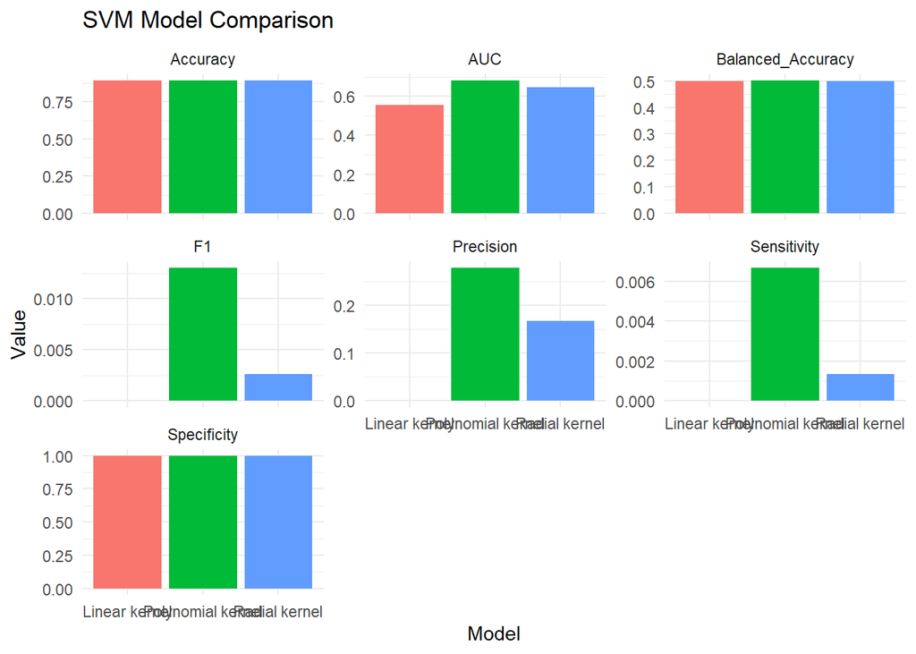

```r
# Create a simple comparison plot

model_results_long <- model_results %>%
  pivot_longer(
    cols = -Model,
    names_to = "Metric",
    values_to = "Value"
  )

ggplot(model_results_long, aes(x = Model, y = Value, fill = Model)) +
  geom_col(show.legend = FALSE) +
  facet_wrap(~ Metric, scales = "free_y") +
  theme_minimal() +
  labs(
    title = "SVM Model Comparison",
    x = "Model",
    y = "Value"
  )
```

The bar charts provide a visual comparison of each model across the reported metrics.

### Model Comparison and Interpretation

The goal is to explain what the pattern of the results demonstrates about diabetes prediction in this dataset.

The final comparison table shows that the polynomial kernel performed best by balanced accuracy and AUC, with balanced accuracy of about `0.502` and AUC of about `0.681`. The radial kernel was slightly behind it, with balanced accuracy of about `0.500` and AUC of about `0.648`, while the linear kernel had balanced accuracy of `0.500` and AUC of about `0.556`. This pattern shows that a nonlinear boundary helps somewhat, but only modestly.

At the same time, the most important finding is that all three models have extremely weak sensitivity. The linear kernel identified no diabetes cases at all, the radial kernel had sensitivity of about `0.001`, and the polynomial kernel had sensitivity of only about `0.007`. In practice, this means the models are predicting the majority `No diabetes` class almost all the time and are missing most of the true diabetes cases. Because of that, the high accuracy values near `0.894` to `0.895` are misleading and mostly reflect class imbalance rather than strong classification performance.

Because the data are observational survey data, predictive relationships should not be interpreted as causal effects. In addition, some demographic variables may improve prediction while also raising interpretation and fairness questions.

### Metrics Meaning

Accuracy measures the overall proportion of correct classifications. Sensitivity measures how well the model identifies respondents who have diabetes. Specificity measures how well the model identifies respondents who do not have diabetes. Precision shows how many of the predicted diabetes cases are truly positive. The F1 score combines precision and sensitivity. Balanced accuracy is helpful when the classes are imbalanced because it averages sensitivity and specificity. AUC measures how well the model ranks positive cases above negative cases across possible classification thresholds.

### SVM Decision Boundary Plot

The assignment requires at least one example SVM decision boundary plot using two strong predictor variables. Following the professor’s style, the plot below uses a direct `svm()` fit with two variables and then uses `plot()` to display the decision boundary.

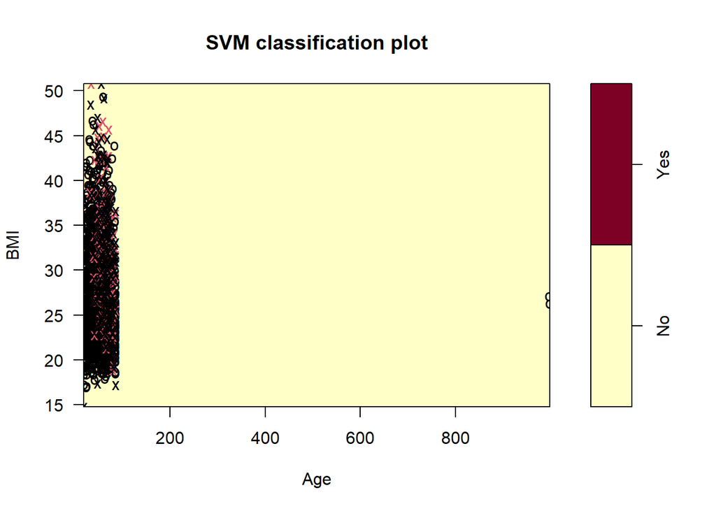

```r
# create a smaller two-variable dataset for the decision boundary plot

svm_plot_data <- nhis_model_data[, c("Diabetes_status", "Age", "BMI")]

set.seed(123)
plot_train <- sample(1:nrow(svm_plot_data), min(2000, nrow(svm_plot_data)))

svm_boundary_model <- svm(
  Diabetes_status ~ Age + BMI,
  data = svm_plot_data[plot_train, ],
  type = "C-classification",
  kernel = "radial",
  gamma = 0.01,
  cost = 1
)

plot(svm_boundary_model, svm_plot_data[plot_train, ], BMI ~ Age)
```

### Critical Thinking

This analysis shows how demographic and health behavior variables can be used to predict disease status, but several limitations remain. First, the NHIS is a survey dataset, so weighted national claims should be made cautiously. Second, complete-case analysis removes observations and may change the makeup of the sample. Third, some predictors may reflect the effects of disease rather than being clear risk factors. For example, lower work hours or lower activity may happen after a diabetes diagnosis rather than before it. Fourth, model performance is shaped by class imbalance, so even a model with good accuracy may still miss many true diabetes cases.

That limitation is especially important here because the final SVM models have sensitivity values near zero and balanced accuracy values only slightly above `0.50`. This means the models do a good job identifying the majority `No diabetes` class but do a poor job detecting respondents who actually have diabetes. From an applied point of view, that is a serious weakness because the positive cases are often the ones of greatest interest in a health-screening setting.

There are also ethical considerations. Predictors such as sex or education may help improve classification, but they also reflect broader social and structural inequalities. A model that uses these variables for prediction should not be interpreted as blaming individuals for disease risk. If this kind of model were ever used for decision-making, fairness, transparency, and the possibility of reinforcing existing disparities would need careful attention.

### Conclusion

This notebook compares linear, radial, and polynomial support vector machines for predicting diabetes in the NHIS adult sample. The polynomial kernel was the best of the three tested models by balanced accuracy and AUC, but its advantage was small and its sensitivity remained extremely low. As a result, the main conclusion is not that the SVMs performed strongly, but that all three models mostly predicted the majority `No diabetes` class and missed many true diabetes cases.